# hw11

**Q1**

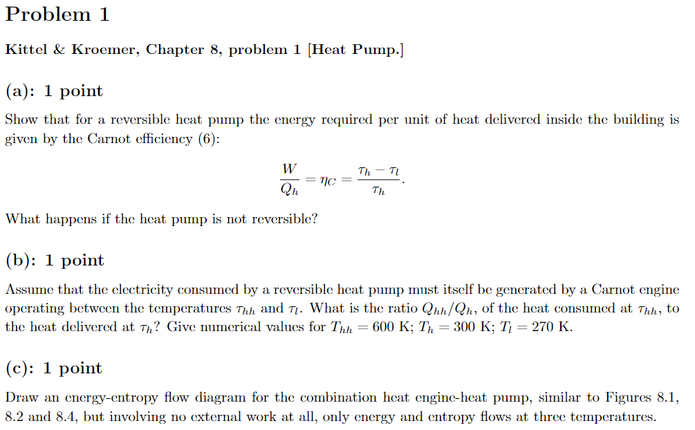

(a) The reversible heat pump: Entropy is constant as work is done

$$ Q = \sigma \tau \\ W = Q_h - Q_l \\ \frac{W}{Q_h} = \frac{Q_h-Q_l}{Q_h} = \frac{\sigma_h \tau_h - \sigma_l \tau_l}{\sigma_h \tau_h} $$

Since this is a reversible process, both $Q_h$ and $Q_l$ occur at the same entropy. If the heat pump was not reversible, the entropy for expansion and compression would be different (usually $\sigma_l$ would be higher, resulting in inefficiency)

$$ = \frac{\sigma_h \tau_h - \sigma_h \tau_l}{\sigma_h \tau_h} = \frac{\tau_h - \tau_l}{ \tau_h} $$

(b) The carnot engine provides work $W = \eta_C Q_{hh}$, giving us

$$ \frac{W}{Q_h} = \frac{\eta_C Q_{hh}}{Q_h} = \frac{\tau_h-\tau_l}{\tau_h} \\ \frac{Q_{hh}}{Q_h} = \frac{1}{\eta_C}\frac{\tau_h-\tau_l}{\tau_h} \\ \eta_C = \frac{\tau_{hh} - \tau_l}{\tau_{hh}} \\ \frac{Q_{hh}}{Q_h} = \frac{\tau_{hh}}{\tau_{hh} - \tau_l} \frac{\tau_h-\tau_l}{\tau_h} $$ The boltzmann constants still cancel out, so we can neglect them when numerically calculating the result. We get resulting ratio

$$ \frac{Q_{hh}}{Q_h} = 0.\overline{18} = \frac{2}{11} $$

```python
thh = 600
th = 300
tl = 270

ratio = thh/th * (th-tl)/(thh-tl)
ratio
```

```
0.18181818181818182
```

Combine 8.1 with 8.4 as the source of work

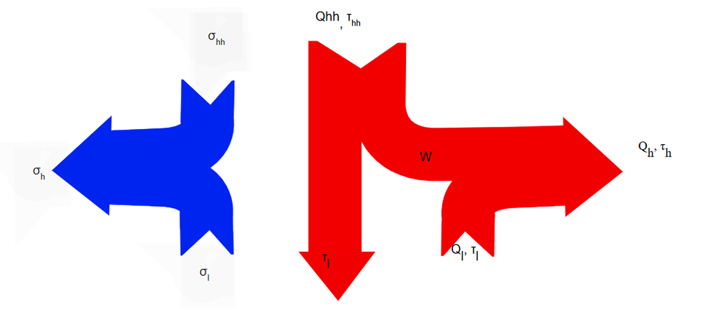

Note there is no net gain of entropy, since we have an ideal carnot and a reversible heat pump

**Q2**

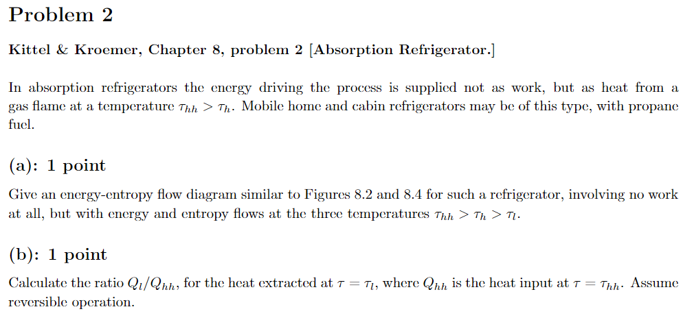

(a) Now with 100% less work!

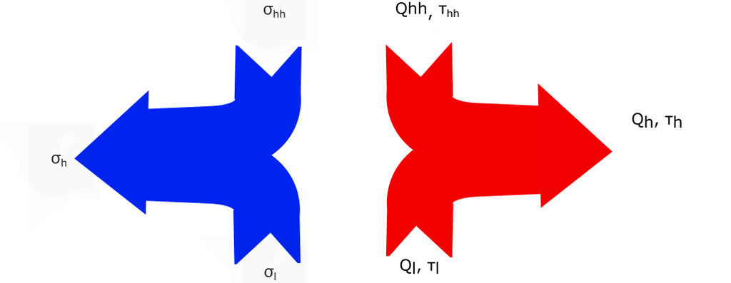

This should be mostly the same as in the previous problem.

$$ Q_h = Q_{hh} + Q_l \\ \sigma_h = \sigma_{hh} + \sigma_{l} \\ $$ At first I was worried that this would result in all temperatures being equal, but these two equations actually give us everything we need for this problem

$$ \frac{Q_h}{\tau_h} = \frac{Q_{hh}}{\tau_{hh}} + \frac{Q_l}{\tau_l} \\ Q_{hh} + Q_l = \frac{\tau_h Q_{hh}}{\tau_{hh}} + \frac{\tau_h Q_l}{\tau_l} \\ 1 + \frac{Q_{l}}{Q_{hh}} = \frac{\tau_h}{\tau_{hh}} + \frac{\tau_h}{\tau_l} \frac{Q_l}{Q_{hh}} \\ \frac{Q_{l}}{Q_{hh}} \left(1 - \frac{\tau_h}{\tau_l}\right) = \frac{\tau_h}{\tau_{hh}} - 1 $$ I could probably have had sympy do all this work

```python
import sympy as sp
ratio, th, tl, thh = sp.symbols('Q_{l}/Q_{hh} tau_h tau_l tau_hh')
sp.solve(sp.Eq(ratio*(1-th/tl), th/thh -1), ratio)[0]
```

$\displaystyle \frac{\tau_{l} \left(- \tau_{h} + \tau_{hh}\right)}{\tau_{hh} \left(\tau_{h} - \tau_{l}\right)}$

$$ \frac{Q_l}{Q_{hh}} = \frac{\tau_l(\tau_{hh} - \tau_h)}{\tau_{hh}(\tau_h - \tau_l)} = \frac{\tau_{hh} - \tau_h}{\tau_{hh}} \frac{\tau_l}{\tau_h - \tau_l} = \eta_C \gamma_C' $$ Not quite the same result as in the previous question. There's still a heat pump powered by a heat pump, but the efficiencies depend on different temperatures.

**Q3**

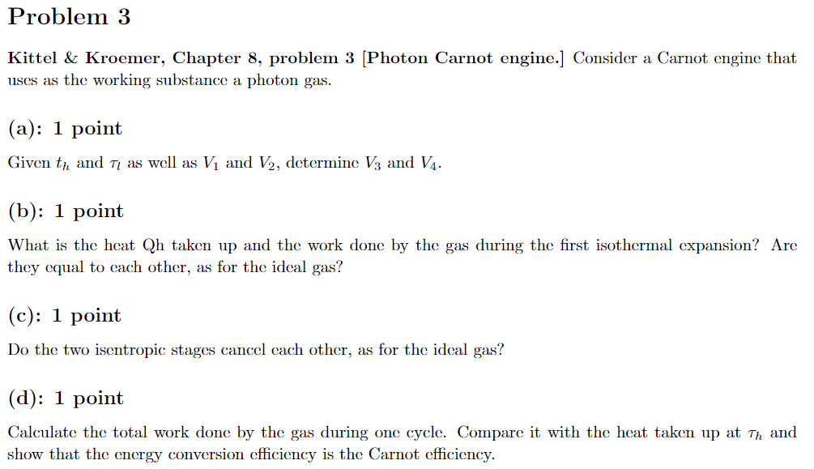

I hope $t_h$ is $\tau_h$. A carnot engine has a square $\tau-\sigma$ diagram.

(a) Looks like these are directly related.

12 is isothermal, 23 is isentropic, 34 isothermal, 41 isentropic. I'm pulling up $F$ for this from a previous homework.

$$ \sigma(\tau_h, V_2) = \sigma(\tau_l, V_3) \\ %Q = 0 \rightarrow dU = dW \sigma = -\frac{\partial F}{\partial \tau} = \frac{4 \tau^3\pi^2 V}{45 \hbar^3 c^3} \\ \sigma_2 = \sigma_3 \\ \tau_h^3 V_2 = \tau_l^3 V_3 \\ V_3 = V_2 \frac{\tau_h^3}{\tau_l^3} $$

Rather than doing some trick with the isothermal process, you can use the same formula on the second isentropic process

$$ V_4 = V_1 \frac{\tau_h^3}{\tau_l^3} $$

(b) We should check what the gas energy is at these points

$$ U = Q + W \\ U = \frac{\pi^2}{15 \hbar^3 c^3} V\tau^4 \\ \Delta U = \frac{a}{15} \tau_h^4 (V_2 - V_1) $$ Where $a$ bundles up all the constants. The heat is much simpler

$$ Q_h = \tau_h (\sigma_H - \sigma_L) = \frac{4a}{45} \tau_h^4 (V_2 -V_1) \\ Q_h > 0 $$

This gives us a different work and heat

$$ W = U-Q = \left(\frac{a}{15} - \frac{4a}{45} \right) \tau_h^4 (V_2 -V_1) = - \frac{a}{45} \tau_h^4 (V_2 - V_1) $$

This is negative since the it is work done on the system (the system is doing work on the surroundings during expansion). The photon gas expends it's internal energy during isothermal expansion |W|>|Q|

(c) Let's check the internal energy change.

$$ U_{2\rightarrow 3} = \frac{a}{15} V_3 \tau_l^4 - \frac{a}{15} V_2 \tau_h^4 \\ U_{4\rightarrow 1} = \frac{a}{15} V_4 \tau_l^4 - \frac{a}{15} V_1 \tau_h^4 \\ $$

Let's see what happens if we reduce our volumes down

$$ U_{2\rightarrow 3} = \frac{a}{15} V_2 \tau_h^3 \tau_l - \frac{a}{15} V_2 \tau_h^4 = \frac{a\tau_h^3}{15} V_2 \left(\tau_l - \tau_h \right)\\ U_{4\rightarrow 1} = \frac{a}{15} V_1 \tau_h^4 - \frac{a}{15} V_1 \tau_h^3 \tau_l = \frac{a\tau_h^3}{15} V_1 \left(\tau_h - \tau_l \right) \\ \frac{U_{4\rightarrow 1}}{U_{2\rightarrow 3}} = -\frac{V_1}{V_2} $$

Since $V_1$ and $V_2$ aren't equivalent, the actions aren't exactly "undone"

(d) No heat during the isentropic process, right? Then $\Delta U = W$ and we can directly copy our equations from (c). We also found work for 12 in B, so we only need 34.

Work during isothermal compression:

$$ W_{3\rightarrow 4} = - \frac{a}{45} \tau_l^4(V_4 - V_3) $$

Thus we have our work from each segment. I'll set $a=1$ since it cancels out in the end and see what sympy can come up with

```python
import sympy as sp
tl, th, v1, v2, v3, v4 = sp.symbols('tau_l tau_h V_1 V_2 V_3 V_4')

W12 = -th**4/45 * (v2-v1)
W23 = th**3/15 * v2 * (tl-th)
W34 = -tl**4/45 * (v4-v3)
W41 = th**3/15 * v1 * (th-tl)
Qh = 4/45 * th**4 * (v2-v1)

ratio = (W12+W23+W34+W41)/Qh
ratio = ratio.subs({v4: v1*th**3/tl**3, v3: v2*th**3/tl**3})
display(ratio)
display(ratio.simplify())
```

$\displaystyle \frac{11.25 \left(\frac{V_{1} \tau_{h}^{3} \left(\tau_{h} - \tau_{l}\right)}{15} + \frac{V_{2} \tau_{h}^{3} \left(- \tau_{h} + \tau_{l}\right)}{15} - \frac{\tau_{h}^{4} \left(- V_{1} + V_{2}\right)}{45} - \frac{\tau_{l}^{4} \left(\frac{V_{1} \tau_{h}^{3}}{\tau_{l}^{3}} - \frac{V_{2} \tau_{h}^{3}}{\tau_{l}^{3}}\right)}{45}\right)}{\tau_{h}^{4} \left(- V_{1} + V_{2}\right)}$

$\displaystyle -1.0 + \frac{1.0 \tau_{l}}{\tau_{h}}$

$$ \frac{W}{Q_h} = \frac{\tau_l}{\tau_h} -1 = -\frac{\tau_h - \tau_l}{\tau_h } = -\eta_C $$

Where $W$ is work done on the system, so work done by the system over heat is $\eta_C$.

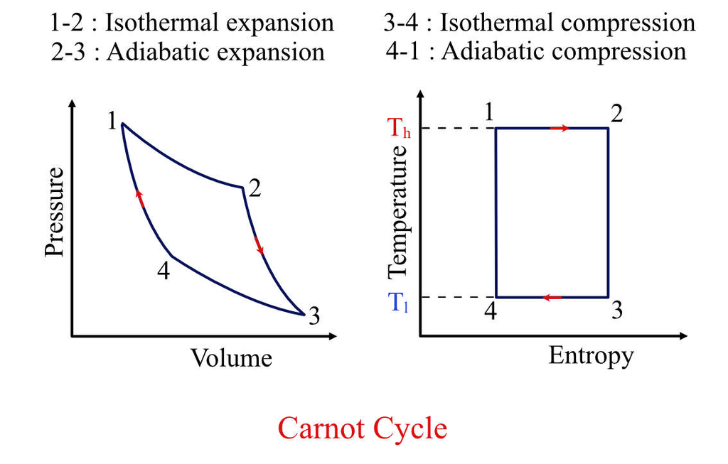

From [eigenplus](https://www.eigenplus.com/carnot-efficiency-formula-derivation-explanation/)

**Q4**

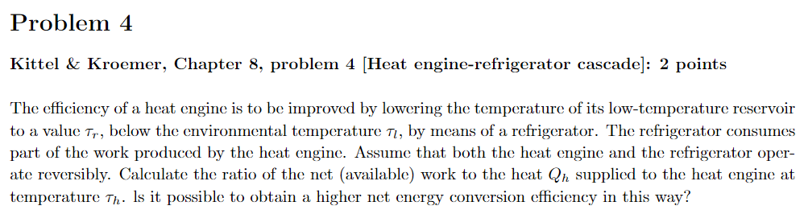

I'll guess the answer is no.

Heat engine efficiency:

$$ \frac{W_C}{Q_h} = \eta_C = \frac{\tau_h - \tau_l}{\tau_h} \\ \frac{Q_{l'}}{W_r} = \gamma_C = \frac{\tau_{l'}}{\tau_{h'}-\tau_{l'}} $$

However, we're plugging in our refridgerator to make a temperature $\tau_r < \tau_l$ for the engine, and we have $W_{r} \leq W_{C}$

$$ \frac{W_C}{Q_h} = \frac{\tau_h - \tau_r}{\tau_h} \\ \frac{Q_r}{W_r} = \gamma_C = \frac{\tau_{r}}{\tau_{l}-\tau_{r}} $$

From this we can find net work / Qh

$$ W_{\text{net}} = W_C - W_r \\ \frac{W_{\text{net}}}{Q_h} = \frac{W_C}{Q_h} - \frac{W_r}{Q_h} = \eta_C - \frac{\tau_l-\tau_r}{\tau_r} \frac{Q_r}{Q_h} $$ Do we have a relation between $Q_h$ and $Q_r$?

$$ \frac{Q_r}{\tau_r} = \frac{Q_h}{\tau_h} \rightarrow Q_r = \frac{\tau_r}{\tau_h}Q_h\\ \frac{W_{\text{net}}}{Q_h} = \eta_C - \frac{\tau_l-\tau_r}{\tau_r} \frac{\tau_r}{\tau_h} \frac{Q_h}{Q_h} \\ = \eta_C - \frac{\tau_l - \tau_r}{\tau_h} $$ Since $\tau_l \geq \tau_r$, this clearly shows that efficiency is maximized when the refridgerator is turned off $\tau_l = \tau_r$

**Q5**

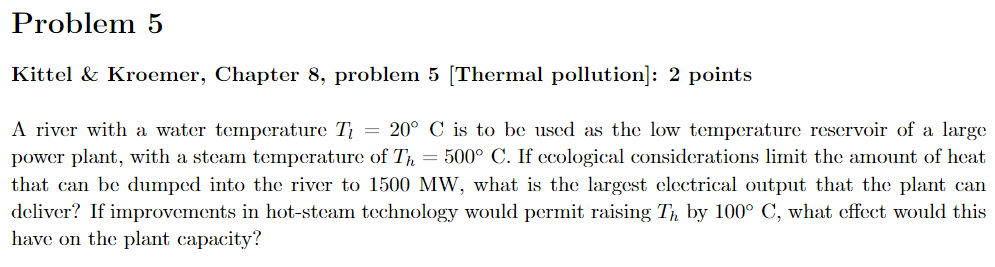

$$ \frac{W}{Q_h} = \frac{T_h - T_l}{T_h} \\ W = 1500 \frac{500-20}{500} = 1440 $$ $T_h$ improvements will improve efficiency, but not by much. $$ W = 1500 \frac{600-20}{600} = 1450 $$

**Q6**

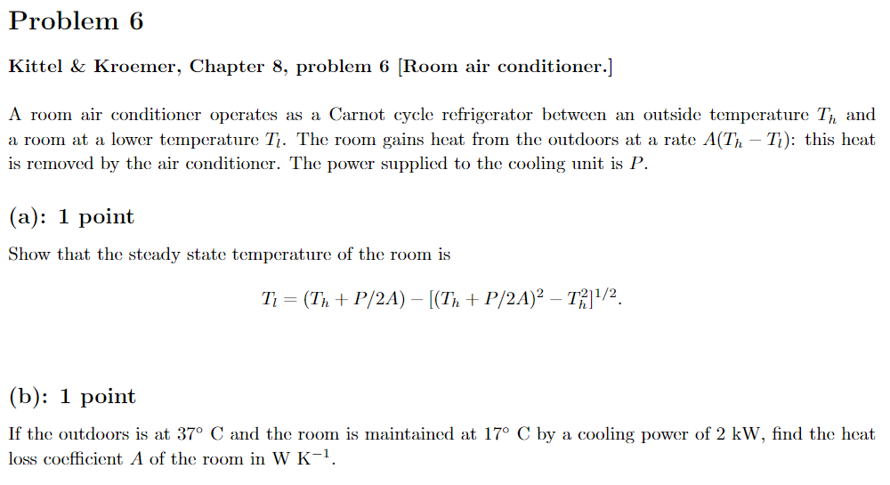

(a) We should probably make a diagram for this refridgerator

What are the units of $A$ to make heat? work/temp

$$ \frac{Q_l}{W} = \gamma_C = \frac{\tau_l}{\tau_h-\tau_l} \\ Q_l = A(T_h - T_l), \quad W=P \\ \frac{A(T_h-T_l)}{P} = \frac{T_l}{T_h-T_l} \\ $$ I'll let sympy do the lifting on this one

```python
import sympy as sp

A, h, l, P = sp.symbols('A T_h T_l P')
steady_eq = sp.Eq(A*(h-l)/P, l/(h-l))
sp.solve(steady_eq, l)[0]
```

$\displaystyle \frac{2 A T_{h} + P - \sqrt{P \left(4 A T_{h} + P\right)}}{2 A}$

```python
steady_eq.subs({l:17+273.15, h:37+273.15, P:2000})
```

$\displaystyle 0.01 A = 14.5075$

This gives A = 1450 W/K